# Analysis of acoustic features: scaled up study

# Load data

```r
# setwd("/Users/seantrott/Dropbox/UCSD/Research/IndirectSpeechActs/Prosody/pros_scaled/src/analysis/audio")
df_audio = read_csv("../../../data/processed/audio/audio_features_scaled_stimuli.csv")
df_audio$label = factor(df_audio$label)
df_audio$form = factor(df_audio$form)

nrow(df_audio)
```

```
## [1] 549
```

```r
table(df_audio$speaker, df_audio$label)
```

```
##
##      question request statement
##   1         6      12         6
##   2         6      12         6
##   3         6      12         6
##   4         6      12         6
##   5         6      12         6
##   6         6      12         6
##   7         6      12         6
##   8         6      12         6
##   9         6      12         6
##   10        3       8         6
##   11        6      12         6
##   12        5      12         5
##   13        6      11         6
##   14        4       9         4
##   15        5       7         2
##   16        6      12         6
##   17        6      12         6
##   18        6      12         6
##   19        6      12         6
##   20        6      12         6
##   21        6      12         6
##   22        6      12         6
##   24        6      12         6
##   25        6      12         6
```

```r
length(unique(df_audio$ppt_id))
```

```
## [1] 24
```

## Remove subjects with less than 24 observations

We also exclude participant 16, who was recorded with a lower-quality laptop microphone. (Note that the exclusion does not really affect the primary outcomes reported.)

```r
n_obs = df_audio %>%
  group_by(ppt_id) %>%
  summarise(count = n())
```

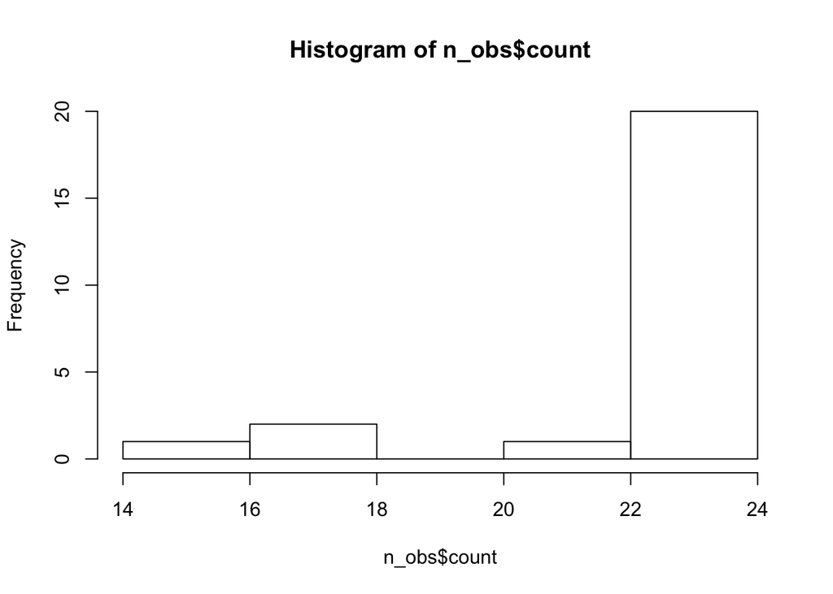

```r
hist(n_obs$count)
```

```r
complete = n_obs %>%
  filter(count == 24)

## print ppt ids with < 24 observations
n_obs %>%
  filter(count < 24)
```

```
## # A tibble: 5 x 2
##   ppt_id count
##    <dbl> <int>
## 1     10    17
## 2     12    22
## 3     13    23
## 4     14    17
## 5     15    14
```

```r
## Select only ppts with 24 observations
df_audio_filtered = df_audio %>%
 filter(ppt_id %in% complete$ppt_id)
nrow(df_audio_filtered)
```

```
## [1] 456
```

```r
## How many remaining?
length(unique(df_audio_filtered$ppt_id))
```

```
## [1] 19
```

```r
## Also remove #16,
df_audio_filtered = df_audio_filtered %>%
 filter(ppt_id != 16)
length(unique(df_audio_filtered$ppt_id))
```

```
## [1] 18
```

```r
unique(df_audio_filtered$ppt_id)
```

```
##  [1] 17  4  9 22  2  3  1 24 21 18  7 19 25  5  8 20  6 11
```

```r
nrow(df_audio_filtered)
```

```
## [1] 432
```

## Descriptive statistics

```r
by_intent = df_audio_filtered %>%
  group_by(label) %>%
  summarise(mean_f0 = mean(mean_f0),
            range_f0 = mean(range_f0),
            sd_f0 = mean(sd_f0),
            duration_f0 = mean(duration_f0),
            slope_f0 = mean(slope_f0),
            mean_intensity = mean(mean_intensity),
            sd_intensity = mean(sd_intensity))
by_intent
```

```
## # A tibble: 3 x 8
##   label  mean_f0 range_f0 sd_f0 duration_f0 slope_f0 mean_intensity sd_intensity
##   <fct>    <dbl>    <dbl> <dbl>       <dbl>    <dbl>          <dbl>        <dbl>
## 1 quest…    165.     156.  31.8        112.  -0.0166           50.8         9.21
## 2 reque…    154.     159.  32.9        106.  -0.316            50.6         8.94
## 3 state…    143.     131.  28.7        100.  -0.371            49.7         8.46
```

## Normalize variables by speaker

Now we z-score our variables, by speaker. E.g., for each speaker, we normalize each observation by z-scoring it *to that speaker*.

```r
df_audio_filtered = df_audio_filtered %>%
  group_by(speaker) %>%
  mutate(mean_f0_z_score = scale(mean_f0),
         duration_f0_z_score = scale(duration_f0),
         range_f0_z_score = scale(range_f0),
         sd_f0_z_score = scale(sd_f0),
         slope_f0_z_score = scale(slope_f0),
         mean_intensity_z_score = scale(mean_intensity),
         sd_intensity_z_score = scale(sd_intensity)
         )
```

# Machine learning classifier

## Do acoustic features help us classify intent overall?

For a first-pass, we recode "statements" and "questions" as non-requests.

```r
df_audio_filtered$label_recoded = fct_recode(df_audio_filtered$label,
                                    "non-request" = "statement",
                                    "non-request" = "question")
```

### Logistic regression

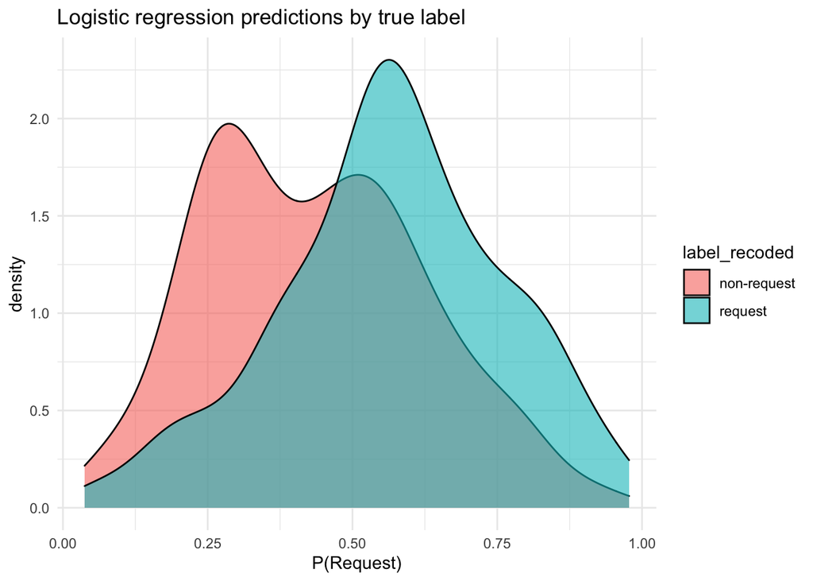

```r
set.seed(123)

df_audio_filtered$index = c(1: nrow(df_audio_filtered))
prob_outputs = c()
for (iterating_index in c(1:nrow(df_audio_filtered))) {

  train = df_audio_filtered %>%
    filter(index != iterating_index)

  test = df_audio_filtered %>%
    filter(index == iterating_index)

  model_core = glm(data = train,
                  label_recoded ~
                    mean_f0_z_score * form +
                    range_f0_z_score * form +
                    sd_f0_z_score * form +
                    duration_f0_z_score * form +
                    slope_f0_z_score * form +
                    mean_intensity_z_score * form +
                    sd_intensity_z_score * form,
                   family = binomial())

  probabilities = predict(model_core, test, type="response")

  prob_outputs[iterating_index] = probabilities
}


df_audio_filtered$lr_probs = prob_outputs

df_audio_filtered %>%
  ggplot(aes(x = lr_probs,
             fill = label_recoded)) +
  geom_density(alpha = .6) +
  labs(x = "P(Request)",
       title = "Logistic regression predictions by true label") +
  theme_minimal()
```

```r
df_audio_filtered$lr_prediction = ifelse(df_audio_filtered$lr_probs > 0.5,
                             "request","non-request")

df_audio_filtered$lr_correct = df_audio_filtered$lr_prediction == df_audio_filtered$label_recoded
mean(df_audio_filtered$lr_correct)
```

```
## [1] 0.6481481
```

We see that a logistic regression classifier equipped with all seven features gives us 65% accuracy on held-out test items.

# Which cues are particularly predictive?

Now, we use nested model comparisons to determine *which cues* are particularly predictive of intent.

## All items

```r
model_all = glm(data = df_audio_filtered,
                  label_recoded ~
                  mean_f0_z_score + range_f0_z_score + sd_f0_z_score + duration_f0_z_score +
                    slope_f0_z_score + mean_intensity_z_score + sd_intensity_z_score,
                   family = binomial())

model_no_mean_f0 = glm(data = df_audio_filtered,
                  label_recoded ~ range_f0_z_score + sd_f0_z_score + duration_f0_z_score +
                    slope_f0_z_score + mean_intensity_z_score + sd_intensity_z_score,
                   family = binomial())

model_no_range_f0 = glm(data = df_audio_filtered,
                  label_recoded ~ mean_f0_z_score + sd_f0_z_score + duration_f0_z_score +
                    slope_f0_z_score + mean_intensity_z_score + sd_intensity_z_score,
                   family = binomial())

model_no_sd_f0 = glm(data = df_audio_filtered,
                  label_recoded ~ mean_f0_z_score + range_f0_z_score + duration_f0_z_score +
                    slope_f0_z_score + mean_intensity_z_score + sd_intensity_z_score,
                   family = binomial())

model_no_duration_f0 = glm(data = df_audio_filtered,
                  label_recoded ~ mean_f0_z_score + range_f0_z_score + sd_f0_z_score +
                    slope_f0_z_score + mean_intensity_z_score + sd_intensity_z_score,
                   family = binomial())

model_no_slope_f0 = glm(data = df_audio_filtered,
                  label_recoded ~ mean_f0_z_score + range_f0_z_score + sd_f0_z_score +
                    duration_f0_z_score + mean_intensity_z_score + sd_intensity_z_score,
                   family = binomial())

model_no_mean_intensity = glm(data = df_audio_filtered,
                  label_recoded ~ mean_f0_z_score + range_f0_z_score + sd_f0_z_score +
                    duration_f0_z_score + slope_f0_z_score + sd_intensity_z_score,
                   family = binomial())

model_no_sd_intensity = glm(data = df_audio_filtered,
                  label_recoded ~ mean_f0_z_score + range_f0_z_score + sd_f0_z_score +
                    duration_f0_z_score + slope_f0_z_score + mean_intensity_z_score,
                   family = binomial())


summary(model_all)
```

```
##
## Call:
## glm(formula = label_recoded ~ mean_f0_z_score + range_f0_z_score +
##     sd_f0_z_score + duration_f0_z_score + slope_f0_z_score +
##     mean_intensity_z_score + sd_intensity_z_score, family = binomial(),
##     data = df_audio_filtered)
##
## Deviance Residuals:
##      Min        1Q    Median        3Q       Max
## -1.79439  -1.14155   0.00836   1.14686   1.66085
##
## Coefficients:
##                          Estimate Std. Error z value Pr(>|z|)
## (Intercept)             0.0006072  0.0978906   0.006  0.99505
## mean_f0_z_score         0.1788978  0.1271845   1.407  0.15955
## range_f0_z_score        0.0831254  0.1980133   0.420  0.67463
## sd_f0_z_score          -0.0515881  0.1991360  -0.259  0.79559
## duration_f0_z_score     0.0983176  0.1113831   0.883  0.37740
## slope_f0_z_score       -0.3306822  0.1171307  -2.823  0.00475 **
## mean_intensity_z_score  0.1839220  0.1060872   1.734  0.08297 .
## sd_intensity_z_score    0.0456789  0.1072024   0.426  0.67004
## ---
## Signif. codes:  0 '***' 0.001 '**' 0.01 '*' 0.05 '.' 0.1 ' ' 1
##
## (Dispersion parameter for binomial family taken to be 1)
##
##     Null deviance: 598.88  on 431  degrees of freedom
## Residual deviance: 584.12  on 424  degrees of freedom
## AIC: 600.12
##
## Number of Fisher Scoring iterations: 4
```

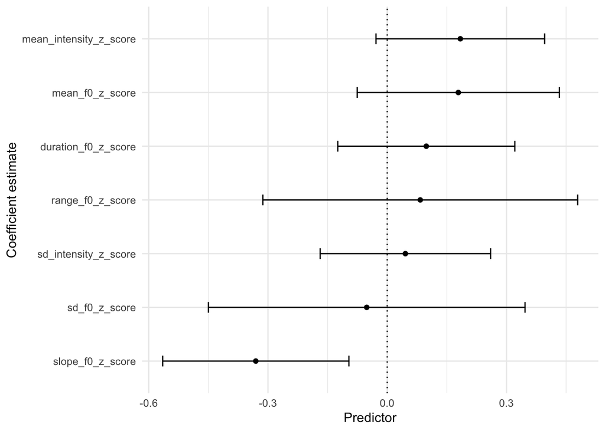

```r
df_broom = broom::tidy(model_all)

df_broom %>%
  filter(term != "(Intercept)") %>%
  ggplot(aes(x = reorder(term, estimate),
             y = estimate)) +
  geom_point() +
  coord_flip() +
  geom_hline(yintercept = 0, linetype = "dotted") +
  geom_errorbar(aes(ymin = estimate - 2*std.error,
                    ymax = estimate + 2*std.error),
                width=.2,
                position=position_dodge(.9)) +
  labs(x = "Coefficient estimate",
       y = "Predictor") +
  theme_minimal()
```

### Model comparisons

```r
mean_f0 = anova(model_no_mean_f0, model_all)
mean_f0
```

```
## Analysis of Deviance Table
##
## Model 1: label_recoded ~ range_f0_z_score + sd_f0_z_score + duration_f0_z_score +
##     slope_f0_z_score + mean_intensity_z_score + sd_intensity_z_score
## Model 2: label_recoded ~ mean_f0_z_score + range_f0_z_score + sd_f0_z_score +
##     duration_f0_z_score + slope_f0_z_score + mean_intensity_z_score +
##     sd_intensity_z_score
##   Resid. Df Resid. Dev Df Deviance
## 1       425     586.12
## 2       424     584.12  1   1.9979
```

```r
p_mean_f0 = pchisq(mean_f0$Deviance[2], mean_f0$Df[2], lower.tail = FALSE)
p_mean_f0
```

```
## [1] 0.1575126
```

```r
range_f0 = anova(model_no_range_f0, model_all)
range_f0
```

```
## Analysis of Deviance Table
##
## Model 1: label_recoded ~ mean_f0_z_score + sd_f0_z_score + duration_f0_z_score +
##     slope_f0_z_score + mean_intensity_z_score + sd_intensity_z_score
## Model 2: label_recoded ~ mean_f0_z_score + range_f0_z_score + sd_f0_z_score +
##     duration_f0_z_score + slope_f0_z_score + mean_intensity_z_score +
##     sd_intensity_z_score
##   Resid. Df Resid. Dev Df Deviance
## 1       425     584.30
## 2       424     584.12  1   0.1766
```

```r
p_range = pchisq(range_f0$Deviance[2], range_f0$Df[2], lower.tail = FALSE)
p_range
```

```
## [1] 0.6743146
```

```r
sd_f0 = anova(model_no_sd_f0, model_all)
sd_f0
```

```
## Analysis of Deviance Table
##
## Model 1: label_recoded ~ mean_f0_z_score + range_f0_z_score + duration_f0_z_score +
##     slope_f0_z_score + mean_intensity_z_score + sd_intensity_z_score
## Model 2: label_recoded ~ mean_f0_z_score + range_f0_z_score + sd_f0_z_score +
##     duration_f0_z_score + slope_f0_z_score + mean_intensity_z_score +
##     sd_intensity_z_score
##   Resid. Df Resid. Dev Df Deviance
## 1       425     584.19
## 2       424     584.12  1 0.067172
```

```r
p_sd_f0 = pchisq(sd_f0$Deviance[2], sd_f0$Df[2], lower.tail = FALSE)

duration_f0 = anova(model_no_duration_f0, model_all)
duration_f0
```

```
## Analysis of Deviance Table
##
## Model 1: label_recoded ~ mean_f0_z_score + range_f0_z_score + sd_f0_z_score +
##     slope_f0_z_score + mean_intensity_z_score + sd_intensity_z_score
## Model 2: label_recoded ~ mean_f0_z_score + range_f0_z_score + sd_f0_z_score +
##     duration_f0_z_score + slope_f0_z_score + mean_intensity_z_score +
##     sd_intensity_z_score
##   Resid. Df Resid. Dev Df Deviance
## 1       425     584.90
## 2       424     584.12  1  0.78211
```

```r
p_duration_f0 = pchisq(duration_f0$Deviance[2], duration_f0$Df[2], lower.tail = FALSE)
p_duration_f0
```

```
## [1] 0.376497
```

```r
slope_f0 = anova(model_no_slope_f0, model_all)
slope_f0
```

```
## Analysis of Deviance Table
##
## Model 1: label_recoded ~ mean_f0_z_score + range_f0_z_score + sd_f0_z_score +
##     duration_f0_z_score + mean_intensity_z_score + sd_intensity_z_score
## Model 2: label_recoded ~ mean_f0_z_score + range_f0_z_score + sd_f0_z_score +
##     duration_f0_z_score + slope_f0_z_score + mean_intensity_z_score +
##     sd_intensity_z_score
##   Resid. Df Resid. Dev Df Deviance
## 1       425     592.48
## 2       424     584.12  1   8.3606
```

```r
p_slope_f0 = pchisq(slope_f0$Deviance[2], slope_f0$Df[2], lower.tail = FALSE)
p_slope_f0
```

```
## [1] 0.003834503
```

```r
mean_intensity = anova(model_no_mean_intensity, model_all)
mean_intensity
```

```
## Analysis of Deviance Table
##
## Model 1: label_recoded ~ mean_f0_z_score + range_f0_z_score + sd_f0_z_score +
##     duration_f0_z_score + slope_f0_z_score + sd_intensity_z_score
## Model 2: label_recoded ~ mean_f0_z_score + range_f0_z_score + sd_f0_z_score +
##     duration_f0_z_score + slope_f0_z_score + mean_intensity_z_score +
##     sd_intensity_z_score
##   Resid. Df Resid. Dev Df Deviance
## 1       425     587.15
## 2       424     584.12  1   3.0289
```

```r
p_mean_intensity = pchisq(mean_intensity$Deviance[2], mean_intensity$Df[2], lower.tail = FALSE)
p_mean_intensity
```

```
## [1] 0.08179521
```

```r
sd_intensity = anova(model_no_sd_intensity, model_all)
sd_intensity
```

```
## Analysis of Deviance Table
##
## Model 1: label_recoded ~ mean_f0_z_score + range_f0_z_score + sd_f0_z_score +
##     duration_f0_z_score + slope_f0_z_score + mean_intensity_z_score
## Model 2: label_recoded ~ mean_f0_z_score + range_f0_z_score + sd_f0_z_score +
##     duration_f0_z_score + slope_f0_z_score + mean_intensity_z_score +
##     sd_intensity_z_score
##   Resid. Df Resid. Dev Df Deviance
## 1       425     584.30
## 2       424     584.12  1  0.18166
```

```r
p_sd_intensity = pchisq(sd_intensity$Deviance[2], sd_intensity$Df[2], lower.tail = FALSE)
p_sd_intensity
```

```
## [1] 0.6699542
```

Now we correct for multiple comparisons:

```r
p.adjust(c(p_mean_f0, p_range, p_sd_f0, p_duration_f0, p_slope_f0,
           p_mean_intensity, p_sd_intensity), method="holm")
```

```
## [1] 0.78756298 1.00000000 1.00000000 1.00000000 0.02684152 0.49077127 1.00000000
```

After correcting for multiple comparisons, only `F0 slope` passes the significance threshold.

## Conventional items

```r
df_conventional = df_audio_filtered %>%
  filter(form == "conventional")

nrow(df_conventional)
```

```
## [1] 216
```

```r
model_all = glm(data = df_conventional,
                  label_recoded ~
                  mean_f0_z_score + range_f0_z_score + sd_f0_z_score + duration_f0_z_score +
                    slope_f0_z_score + mean_intensity_z_score + sd_intensity_z_score,
                   family = binomial())

model_no_mean_f0 = glm(data = df_conventional,
                  label_recoded ~ range_f0_z_score + sd_f0_z_score + duration_f0_z_score +
                    slope_f0_z_score + mean_intensity_z_score + sd_intensity_z_score,
                   family = binomial())

model_no_range_f0 = glm(data = df_conventional,
                  label_recoded ~ mean_f0_z_score + sd_f0_z_score + duration_f0_z_score +
                    slope_f0_z_score + mean_intensity_z_score + sd_intensity_z_score,
                   family = binomial())

model_no_sd_f0 = glm(data = df_conventional,
                  label_recoded ~ mean_f0_z_score + range_f0_z_score + duration_f0_z_score +
                    slope_f0_z_score + mean_intensity_z_score + sd_intensity_z_score,
                   family = binomial())

model_no_duration_f0 = glm(data = df_conventional,
                  label_recoded ~ mean_f0_z_score + range_f0_z_score + sd_f0_z_score +
                    slope_f0_z_score + mean_intensity_z_score + sd_intensity_z_score,
                   family = binomial())

model_no_slope_f0 = glm(data = df_conventional,
                  label_recoded ~ mean_f0_z_score + range_f0_z_score + sd_f0_z_score +
                    duration_f0_z_score + mean_intensity_z_score + sd_intensity_z_score,
                   family = binomial())

model_no_mean_intensity = glm(data = df_conventional,
                  label_recoded ~ mean_f0_z_score + range_f0_z_score + sd_f0_z_score +
                    duration_f0_z_score + slope_f0_z_score + sd_intensity_z_score,
                   family = binomial())

model_no_sd_intensity = glm(data = df_conventional,
                  label_recoded ~ mean_f0_z_score + range_f0_z_score + sd_f0_z_score +
                    duration_f0_z_score + slope_f0_z_score + mean_intensity_z_score,
                   family = binomial())


summary(model_all)
```

```
##
## Call:
## glm(formula = label_recoded ~ mean_f0_z_score + range_f0_z_score +
##     sd_f0_z_score + duration_f0_z_score + slope_f0_z_score +
##     mean_intensity_z_score + sd_intensity_z_score, family = binomial(),
##     data = df_conventional)
##
## Deviance Residuals:
##     Min       1Q   Median       3Q      Max
## -1.9414  -1.0857   0.1263   1.0583   2.2969
##
## Coefficients:
##                         Estimate Std. Error z value Pr(>|z|)
## (Intercept)             0.123895   0.179820   0.689  0.49083
## mean_f0_z_score        -0.361399   0.204846  -1.764  0.07769 .
## range_f0_z_score        0.302810   0.292767   1.034  0.30099
## sd_f0_z_score          -0.107383   0.293827  -0.365  0.71477
## duration_f0_z_score    -0.754891   0.203631  -3.707  0.00021 ***
## slope_f0_z_score       -0.331499   0.168131  -1.972  0.04865 *
## mean_intensity_z_score  0.451502   0.165109   2.735  0.00625 **
## sd_intensity_z_score   -0.008836   0.169765  -0.052  0.95849
## ---
## Signif. codes:  0 '***' 0.001 '**' 0.01 '*' 0.05 '.' 0.1 ' ' 1
##
## (Dispersion parameter for binomial family taken to be 1)
##
##     Null deviance: 299.44  on 215  degrees of freedom
## Residual deviance: 269.88  on 208  degrees of freedom
## AIC: 285.88
##
## Number of Fisher Scoring iterations: 4
```

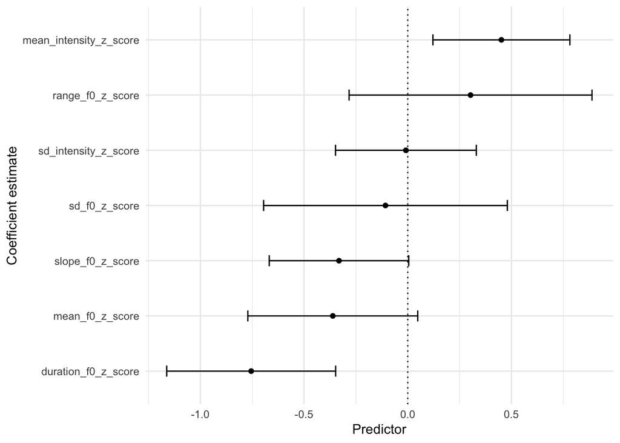

```r
df_broom = broom::tidy(model_all)

df_broom %>%
  filter(term != "(Intercept)") %>%
  ggplot(aes(x = reorder(term, estimate),
             y = estimate)) +
  geom_point() +
  coord_flip() +
  geom_hline(yintercept = 0, linetype = "dotted") +
  geom_errorbar(aes(ymin = estimate - 2*std.error,
                    ymax = estimate + 2*std.error),
                width=.2,
                position=position_dodge(.9)) +
  labs(x = "Coefficient estimate",
       y = "Predictor") +
  theme_minimal()
```

### Model comparisons

```r
mean_f0 = anova(model_no_mean_f0, model_all)
mean_f0
```

```
## Analysis of Deviance Table
##
## Model 1: label_recoded ~ range_f0_z_score + sd_f0_z_score + duration_f0_z_score +
##     slope_f0_z_score + mean_intensity_z_score + sd_intensity_z_score
## Model 2: label_recoded ~ mean_f0_z_score + range_f0_z_score + sd_f0_z_score +
##     duration_f0_z_score + slope_f0_z_score + mean_intensity_z_score +
##     sd_intensity_z_score
##   Resid. Df Resid. Dev Df Deviance
## 1       209     273.07
## 2       208     269.88  1   3.1928
```

```r
p_mean_f0 = pchisq(mean_f0$Deviance[2], mean_f0$Df[2], lower.tail = FALSE)
p_mean_f0
```

```
## [1] 0.0739611
```

```r
range_f0 = anova(model_no_range_f0, model_all)
range_f0
```

```
## Analysis of Deviance Table
##
## Model 1: label_recoded ~ mean_f0_z_score + sd_f0_z_score + duration_f0_z_score +
##     slope_f0_z_score + mean_intensity_z_score + sd_intensity_z_score
## Model 2: label_recoded ~ mean_f0_z_score + range_f0_z_score + sd_f0_z_score +
##     duration_f0_z_score + slope_f0_z_score + mean_intensity_z_score +
##     sd_intensity_z_score
##   Resid. Df Resid. Dev Df Deviance
## 1       209     270.96
## 2       208     269.88  1   1.0823
```

```r
p_range = pchisq(range_f0$Deviance[2], range_f0$Df[2], lower.tail = FALSE)
p_range
```

```
## [1] 0.2981829
```

```r
sd_f0 = anova(model_no_sd_f0, model_all)
sd_f0
```

```
## Analysis of Deviance Table
##
## Model 1: label_recoded ~ mean_f0_z_score + range_f0_z_score + duration_f0_z_score +
##     slope_f0_z_score + mean_intensity_z_score + sd_intensity_z_score
## Model 2: label_recoded ~ mean_f0_z_score + range_f0_z_score + sd_f0_z_score +
##     duration_f0_z_score + slope_f0_z_score + mean_intensity_z_score +
##     sd_intensity_z_score
##   Resid. Df Resid. Dev Df Deviance
## 1       209     270.01
## 2       208     269.88  1  0.13387
```

```r
p_sd_f0 = pchisq(sd_f0$Deviance[2], sd_f0$Df[2], lower.tail = FALSE)

duration_f0 = anova(model_no_duration_f0, model_all)
duration_f0
```

```
## Analysis of Deviance Table
##
## Model 1: label_recoded ~ mean_f0_z_score + range_f0_z_score + sd_f0_z_score +
##     slope_f0_z_score + mean_intensity_z_score + sd_intensity_z_score
## Model 2: label_recoded ~ mean_f0_z_score + range_f0_z_score + sd_f0_z_score +
##     duration_f0_z_score + slope_f0_z_score + mean_intensity_z_score +
##     sd_intensity_z_score
##   Resid. Df Resid. Dev Df Deviance
## 1       209     285.80
## 2       208     269.88  1   15.927
```

```r
p_duration_f0 = pchisq(duration_f0$Deviance[2], duration_f0$Df[2], lower.tail = FALSE)
p_duration_f0
```

```
## [1] 6.582484e-05
```

```r
slope_f0 = anova(model_no_slope_f0, model_all)
slope_f0
```

```
## Analysis of Deviance Table
##
## Model 1: label_recoded ~ mean_f0_z_score + range_f0_z_score + sd_f0_z_score +
##     duration_f0_z_score + mean_intensity_z_score + sd_intensity_z_score
## Model 2: label_recoded ~ mean_f0_z_score + range_f0_z_score + sd_f0_z_score +
##     duration_f0_z_score + slope_f0_z_score + mean_intensity_z_score +
##     sd_intensity_z_score
##   Resid. Df Resid. Dev Df Deviance
## 1       209     273.94
## 2       208     269.88  1   4.0588
```

```r
p_slope_f0 = pchisq(slope_f0$Deviance[2], slope_f0$Df[2], lower.tail = FALSE)
p_slope_f0
```

```
## [1] 0.04394269
```

```r
mean_intensity = anova(model_no_mean_intensity, model_all)
mean_intensity
```

```
## Analysis of Deviance Table
##
## Model 1: label_recoded ~ mean_f0_z_score + range_f0_z_score + sd_f0_z_score +
##     duration_f0_z_score + slope_f0_z_score + sd_intensity_z_score
## Model 2: label_recoded ~ mean_f0_z_score + range_f0_z_score + sd_f0_z_score +
##     duration_f0_z_score + slope_f0_z_score + mean_intensity_z_score +
##     sd_intensity_z_score
##   Resid. Df Resid. Dev Df Deviance
## 1       209     277.78
## 2       208     269.88  1   7.9003
```

```r
p_mean_intensity = pchisq(mean_intensity$Deviance[2], mean_intensity$Df[2], lower.tail = FALSE)
p_mean_intensity
```

```
## [1] 0.004942756
```

```r
sd_intensity = anova(model_no_sd_intensity, model_all)
sd_intensity
```

```
## Analysis of Deviance Table
##
## Model 1: label_recoded ~ mean_f0_z_score + range_f0_z_score + sd_f0_z_score +
##     duration_f0_z_score + slope_f0_z_score + mean_intensity_z_score
## Model 2: label_recoded ~ mean_f0_z_score + range_f0_z_score + sd_f0_z_score +
##     duration_f0_z_score + slope_f0_z_score + mean_intensity_z_score +
##     sd_intensity_z_score
##   Resid. Df Resid. Dev Df  Deviance
## 1       209     269.88
## 2       208     269.88  1 0.0027092
```

```r
p_sd_intensity = pchisq(sd_intensity$Deviance[2], sd_intensity$Df[2], lower.tail = FALSE)
p_sd_intensity
```

```
## [1] 0.9584893
```

Now we correct for multiple comparisons:

```r
p.adjust(c(p_mean_f0, p_range, p_sd_f0, p_duration_f0, p_slope_f0,
           p_mean_intensity, p_sd_intensity), method="holm")
```

```
## [1] 0.2958444151 0.8945485652 1.0000000000 0.0004607739 0.2197134331
## [6] 0.0296565379 1.0000000000
```

After correcting for multiple comparisons, only `F0 duration` and `mean intensity` pass the significance threshold. `F0 slope`, which was found to be predictive in previous analyses, is no longer significant after correcting for multiple comparisons (before correcting it is marginally significant: 0.0439427).

## Non-conventional items

```r
df_nonconventional = df_audio_filtered %>%
  filter(form == "non-conventional")

nrow(df_nonconventional)
```

```
## [1] 216
```

```r
model_all = glm(data = df_nonconventional,
                  label_recoded ~
                  mean_f0_z_score + range_f0_z_score + sd_f0_z_score + duration_f0_z_score +
                    slope_f0_z_score + mean_intensity_z_score + sd_intensity_z_score,
                   family = binomial())

model_no_mean_f0 = glm(data = df_nonconventional,
                  label_recoded ~ range_f0_z_score + sd_f0_z_score + duration_f0_z_score +
                    slope_f0_z_score + mean_intensity_z_score + sd_intensity_z_score,
                   family = binomial())

model_no_range_f0 = glm(data = df_nonconventional,
                  label_recoded ~ mean_f0_z_score + sd_f0_z_score + duration_f0_z_score +
                    slope_f0_z_score + mean_intensity_z_score + sd_intensity_z_score,
                   family = binomial())

model_no_sd_f0 = glm(data = df_nonconventional,
                  label_recoded ~ mean_f0_z_score + range_f0_z_score + duration_f0_z_score +
                    slope_f0_z_score + mean_intensity_z_score + sd_intensity_z_score,
                   family = binomial())

model_no_duration_f0 = glm(data = df_nonconventional,
                  label_recoded ~ mean_f0_z_score + range_f0_z_score + sd_f0_z_score +
                    slope_f0_z_score + mean_intensity_z_score + sd_intensity_z_score,
                   family = binomial())

model_no_slope_f0 = glm(data = df_nonconventional,
                  label_recoded ~ mean_f0_z_score + range_f0_z_score + sd_f0_z_score +
                    duration_f0_z_score + mean_intensity_z_score + sd_intensity_z_score,
                   family = binomial())

model_no_mean_intensity = glm(data = df_nonconventional,
                  label_recoded ~ mean_f0_z_score + range_f0_z_score + sd_f0_z_score +
                    duration_f0_z_score + slope_f0_z_score + sd_intensity_z_score,
                   family = binomial())

model_no_sd_intensity = glm(data = df_nonconventional,
                  label_recoded ~ mean_f0_z_score + range_f0_z_score + sd_f0_z_score +
                    duration_f0_z_score + slope_f0_z_score + mean_intensity_z_score,
                   family = binomial())


summary(model_all)
```

```
##
## Call:
## glm(formula = label_recoded ~ mean_f0_z_score + range_f0_z_score +
##     sd_f0_z_score + duration_f0_z_score + slope_f0_z_score +
##     mean_intensity_z_score + sd_intensity_z_score, family = binomial(),
##     data = df_nonconventional)
##
## Deviance Residuals:
##      Min        1Q    Median        3Q       Max
## -2.18850  -0.95018  -0.07728   1.00641   2.20690
##
## Coefficients:
##                        Estimate Std. Error z value Pr(>|z|)
## (Intercept)             0.53118    0.20778   2.556   0.0106 *
## mean_f0_z_score         1.18130    0.26289   4.494 7.00e-06 ***
## range_f0_z_score       -0.60767    0.32689  -1.859   0.0630 .
## sd_f0_z_score           0.49430    0.33000   1.498   0.1342
## duration_f0_z_score     0.93756    0.19147   4.897 9.75e-07 ***
## slope_f0_z_score       -0.42361    0.20888  -2.028   0.0426 *
## mean_intensity_z_score  0.02628    0.18461   0.142   0.8868
## sd_intensity_z_score    0.18684    0.18143   1.030   0.3031
## ---
## Signif. codes:  0 '***' 0.001 '**' 0.01 '*' 0.05 '.' 0.1 ' ' 1
##
## (Dispersion parameter for binomial family taken to be 1)
##
##     Null deviance: 299.44  on 215  degrees of freedom
## Residual deviance: 252.67  on 208  degrees of freedom
## AIC: 268.67
##
## Number of Fisher Scoring iterations: 4
```

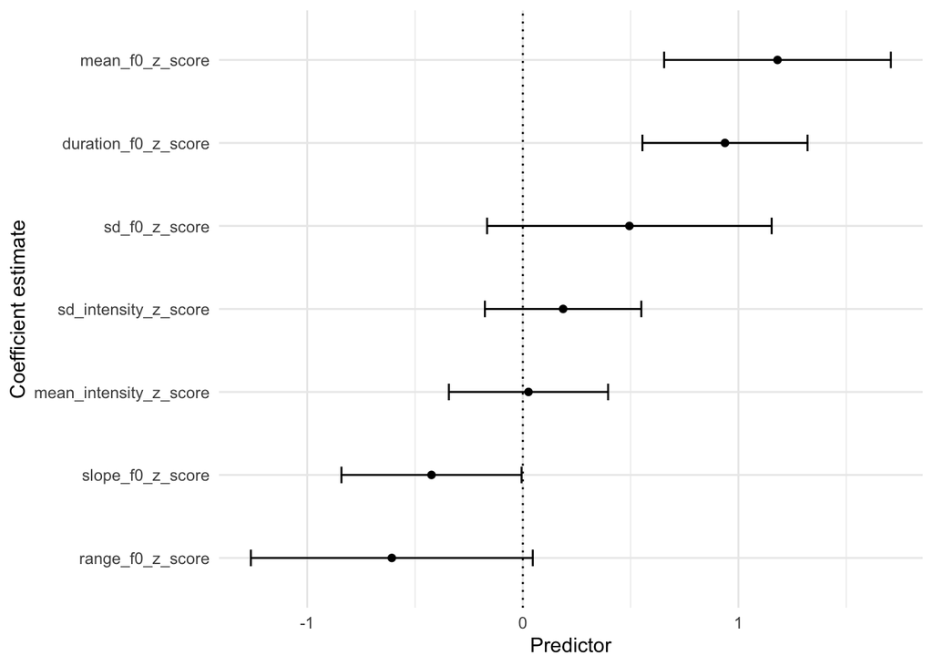

```r
df_broom = broom::tidy(model_all)

df_broom %>%
  filter(term != "(Intercept)") %>%
  ggplot(aes(x = reorder(term, estimate),
             y = estimate)) +
  geom_point() +
  coord_flip() +
  geom_hline(yintercept = 0, linetype = "dotted") +
  geom_errorbar(aes(ymin = estimate - 2*std.error,
                    ymax = estimate + 2*std.error),
                width=.2,
                position=position_dodge(.9)) +
  labs(x = "Coefficient estimate",
       y = "Predictor") +
  theme_minimal()
```

### Model comparisons

```r
mean_f0 = anova(model_no_mean_f0, model_all)
mean_f0
```

```
## Analysis of Deviance Table
##
## Model 1: label_recoded ~ range_f0_z_score + sd_f0_z_score + duration_f0_z_score +
##     slope_f0_z_score + mean_intensity_z_score + sd_intensity_z_score
## Model 2: label_recoded ~ mean_f0_z_score + range_f0_z_score + sd_f0_z_score +
##     duration_f0_z_score + slope_f0_z_score + mean_intensity_z_score +
##     sd_intensity_z_score
##   Resid. Df Resid. Dev Df Deviance
## 1       209     277.66
## 2       208     252.67  1   24.988
```

```r
p_mean_f0 = pchisq(mean_f0$Deviance[2], mean_f0$Df[2], lower.tail = FALSE)
p_mean_f0
```

```
## [1] 5.770228e-07
```

```r
range_f0 = anova(model_no_range_f0, model_all)
range_f0
```

```
## Analysis of Deviance Table
##
## Model 1: label_recoded ~ mean_f0_z_score + sd_f0_z_score + duration_f0_z_score +
##     slope_f0_z_score + mean_intensity_z_score + sd_intensity_z_score
## Model 2: label_recoded ~ mean_f0_z_score + range_f0_z_score + sd_f0_z_score +
##     duration_f0_z_score + slope_f0_z_score + mean_intensity_z_score +
##     sd_intensity_z_score
##   Resid. Df Resid. Dev Df Deviance
## 1       209     256.26
## 2       208     252.67  1    3.583
```

```r
p_range = pchisq(range_f0$Deviance[2], range_f0$Df[2], lower.tail = FALSE)
p_range
```

```
## [1] 0.05837504
```

```r
sd_f0 = anova(model_no_sd_f0, model_all)
sd_f0
```

```
## Analysis of Deviance Table
##
## Model 1: label_recoded ~ mean_f0_z_score + range_f0_z_score + duration_f0_z_score +
##     slope_f0_z_score + mean_intensity_z_score + sd_intensity_z_score
## Model 2: label_recoded ~ mean_f0_z_score + range_f0_z_score + sd_f0_z_score +
##     duration_f0_z_score + slope_f0_z_score + mean_intensity_z_score +
##     sd_intensity_z_score
##   Resid. Df Resid. Dev Df Deviance
## 1       209     254.97
## 2       208     252.67  1   2.2909
```

```r
p_sd_f0 = pchisq(sd_f0$Deviance[2], sd_f0$Df[2], lower.tail = FALSE)

duration_f0 = anova(model_no_duration_f0, model_all)
duration_f0
```

```
## Analysis of Deviance Table
##
## Model 1: label_recoded ~ mean_f0_z_score + range_f0_z_score + sd_f0_z_score +
##     slope_f0_z_score + mean_intensity_z_score + sd_intensity_z_score
## Model 2: label_recoded ~ mean_f0_z_score + range_f0_z_score + sd_f0_z_score +
##     duration_f0_z_score + slope_f0_z_score + mean_intensity_z_score +
##     sd_intensity_z_score
##   Resid. Df Resid. Dev Df Deviance
## 1       209     281.74
## 2       208     252.67  1   29.064
```

```r
p_duration_f0 = pchisq(duration_f0$Deviance[2], duration_f0$Df[2], lower.tail = FALSE)
p_duration_f0
```

```
## [1] 7.003302e-08
```

```r
slope_f0 = anova(model_no_slope_f0, model_all)
slope_f0
```

```
## Analysis of Deviance Table
##
## Model 1: label_recoded ~ mean_f0_z_score + range_f0_z_score + sd_f0_z_score +
##     duration_f0_z_score + mean_intensity_z_score + sd_intensity_z_score
## Model 2: label_recoded ~ mean_f0_z_score + range_f0_z_score + sd_f0_z_score +
##     duration_f0_z_score + slope_f0_z_score + mean_intensity_z_score +
##     sd_intensity_z_score
##   Resid. Df Resid. Dev Df Deviance
## 1       209     256.94
## 2       208     252.67  1   4.2648
```

```r
p_slope_f0 = pchisq(slope_f0$Deviance[2], slope_f0$Df[2], lower.tail = FALSE)
p_slope_f0
```

```
## [1] 0.0389094
```

```r
mean_intensity = anova(model_no_mean_intensity, model_all)
mean_intensity
```

```
## Analysis of Deviance Table
##
## Model 1: label_recoded ~ mean_f0_z_score + range_f0_z_score + sd_f0_z_score +
##     duration_f0_z_score + slope_f0_z_score + sd_intensity_z_score
## Model 2: label_recoded ~ mean_f0_z_score + range_f0_z_score + sd_f0_z_score +
##     duration_f0_z_score + slope_f0_z_score + mean_intensity_z_score +
##     sd_intensity_z_score
##   Resid. Df Resid. Dev Df Deviance
## 1       209     252.69
## 2       208     252.67  1 0.020272
```

```r
p_mean_intensity = pchisq(mean_intensity$Deviance[2], mean_intensity$Df[2], lower.tail = FALSE)
p_mean_intensity
```

```
## [1] 0.8867798
```

```r
sd_intensity = anova(model_no_sd_intensity, model_all)
sd_intensity
```

```
## Analysis of Deviance Table
##
## Model 1: label_recoded ~ mean_f0_z_score + range_f0_z_score + sd_f0_z_score +
##     duration_f0_z_score + slope_f0_z_score + mean_intensity_z_score
## Model 2: label_recoded ~ mean_f0_z_score + range_f0_z_score + sd_f0_z_score +
##     duration_f0_z_score + slope_f0_z_score + mean_intensity_z_score +
##     sd_intensity_z_score
##   Resid. Df Resid. Dev Df Deviance
## 1       209     253.75
## 2       208     252.67  1   1.0714
```

```r
p_sd_intensity = pchisq(sd_intensity$Deviance[2], sd_intensity$Df[2], lower.tail = FALSE)
p_sd_intensity
```

```
## [1] 0.3006271
```

Now we correct for multiple comparisons:

```r
p.adjust(c(p_mean_f0, p_range, p_sd_f0, p_duration_f0, p_slope_f0,
           p_mean_intensity, p_sd_intensity), method="holm")
```

```
## [1] 3.462137e-06 2.335002e-01 3.904064e-01 4.902312e-07 1.945470e-01
## [6] 8.867798e-01 6.012541e-01
```

After correcting for multiple comparisons, we see that `F0 mean` and `F0 duration` are significantly predictive of intent.

### Visualizations

The features that were most predictive in the analyses above were:

- **#voiced frames** (for both)
- **mean intensity** (for conventional items)
- **mean F0** (for non-conventional items)
- **F0 slope** (marginally predictive for conventional items).

Let's visualize them below:

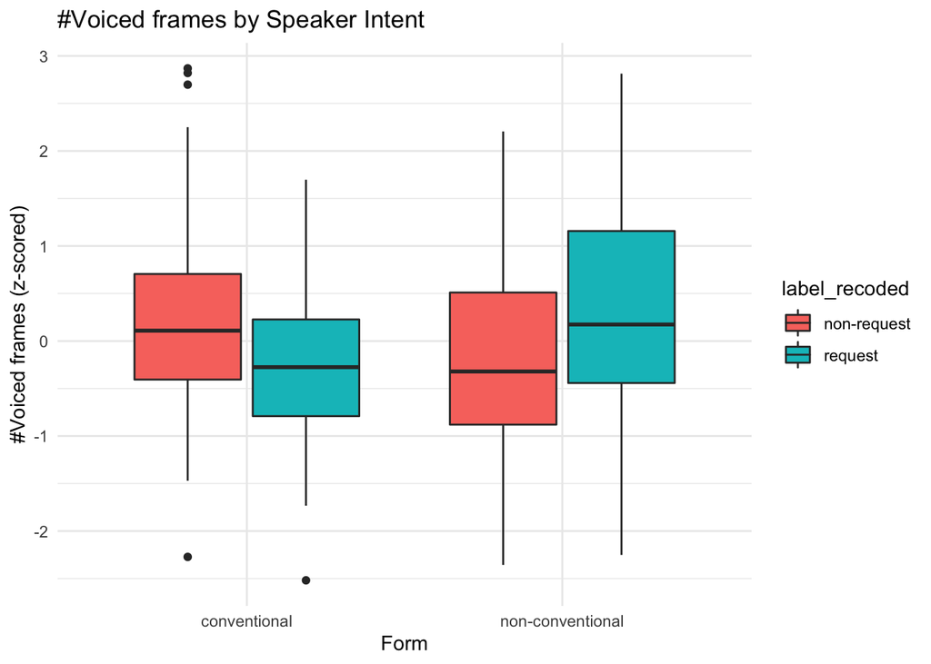

```r
df_audio_filtered %>%
  ggplot(aes(x = form,
             y = duration_f0_z_score,
             fill = label_recoded)) +
  geom_boxplot() +
  labs(x = "Form",
       y = "#Voiced frames (z-scored)",
       title = "#Voiced frames by Speaker Intent") +
  theme_minimal()
```

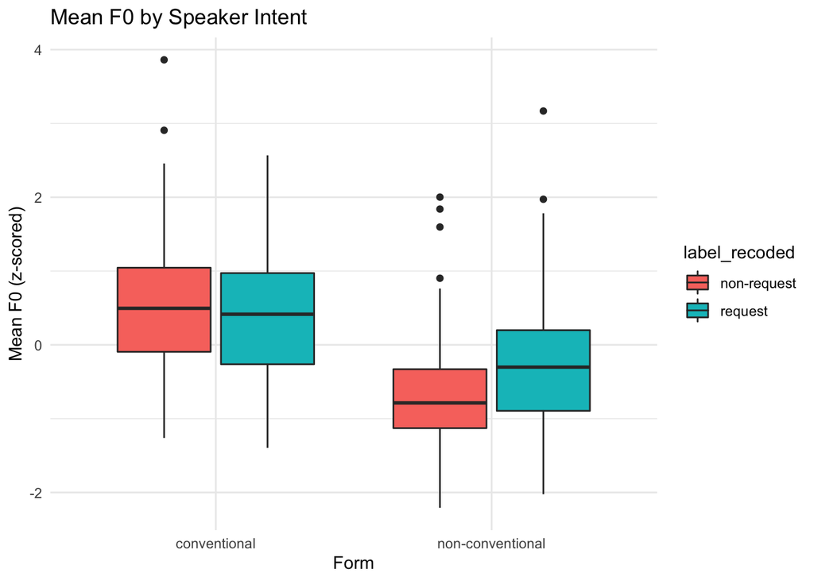

```r
df_audio_filtered %>%
  ggplot(aes(x = form,
             y = mean_f0_z_score,
             fill = label_recoded)) +
  geom_boxplot() +
  labs(x = "Form",
       y = "Mean F0 (z-scored)",
       title = "Mean F0 by Speaker Intent") +
  theme_minimal()
```

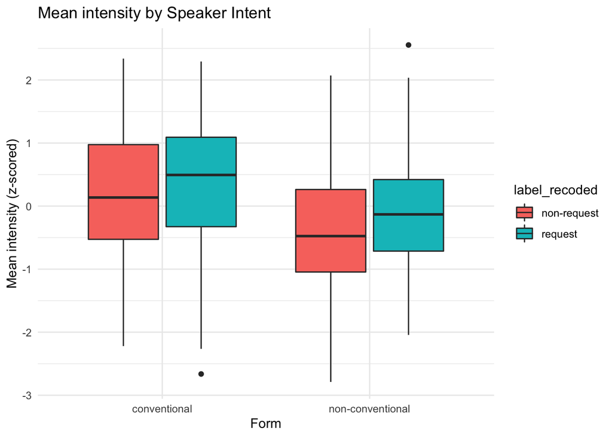

```r
df_audio_filtered %>%
  ggplot(aes(x = form,
             y = mean_intensity_z_score,
             fill = label_recoded)) +
  geom_boxplot() +
  labs(x = "Form",
       y = "Mean intensity (z-scored)",
       title = "Mean intensity by Speaker Intent") +
  theme_minimal()
```

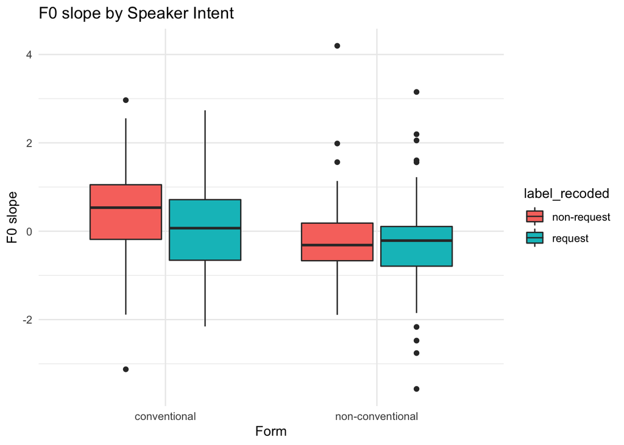

```r
df_audio_filtered %>%
  ggplot(aes(x = form,
             y = slope_f0_z_score,
             fill = label_recoded)) +
  geom_boxplot() +
  labs(x = "Form",
       y = "F0 slope",
       title = "F0 slope by Speaker Intent") +
  theme_minimal()
```